# Loan Approval Status

TEAM 7- Richik Ghosh, Shreya Sahay, Sanika Narayanapethkar, Vamsidhar Boddu

2023-12-13

```r
library(ezids)
library(ggplot2)
library(gridExtra)
library(stringr)
library(corrplot)
library(RColorBrewer)
library(scales)
library(dplyr)
library("car")
library("class")
library("pROC")
```

# Importing the Data

```r
data_pre<-data.frame(read.csv("loan_approval_dataset.csv"))
data<-data_pre
```

# Structure of the data

```r
str(data)
```

```
## 'data.frame':    4269 obs. of  13 variables:
##  $ loan_id                 : int  1 2 3 4 5 6 7 8 9 10 ...
##  $ no_of_dependents        : int  2 0 3 3 5 0 5 2 0 5 ...
##  $ education               : chr  " Graduate" " Not Graduate" " Graduate" " Graduate" ...
##  $ self_employed           : chr  " No" " Yes" " No" " No" ...
##  $ income_annum            : int  9600000 4100000 9100000 8200000 9800000 4800000 8700000 5700000 800000 1100000 ...
##  $ loan_amount             : int  29900000 12200000 29700000 30700000 24200000 13500000 33000000 15000000 2200000 4300000 ...
##  $ loan_term               : int  12 8 20 8 20 10 4 20 20 10 ...
##  $ cibil_score             : int  778 417 506 467 382 319 678 382 782 388 ...
##  $ residential_assets_value: int  2400000 2700000 7100000 18200000 12400000 6800000 22500000 13200000 1300000 3200000 ...
##  $ commercial_assets_value : int  17600000 2200000 4500000 3300000 8200000 8300000 14800000 5700000 800000 1400000 ...
##  $ luxury_assets_value     : int  22700000 8800000 33300000 23300000 29400000 13700000 29200000 11800000 2800000 3300000 ...
##  $ bank_asset_value        : int  8000000 3300000 12800000 7900000 5000000 5100000 4300000 6000000 600000 1600000 ...
##  $ loan_status             : chr  " Approved" " Rejected" " Rejected" " Rejected" ...
```

```r
NA_values <- sum(is.na(data))
NA_values
```

```r
data<- subset(data_pre, select = -c(loan_id))
```

```r
data$education <- as.factor(data$education)
data$self_employed<-as.factor(data$self_employed)
data$loan_status<-as.factor(data$loan_status)

str(data)
```

```r
summary(data)
```

# EDA

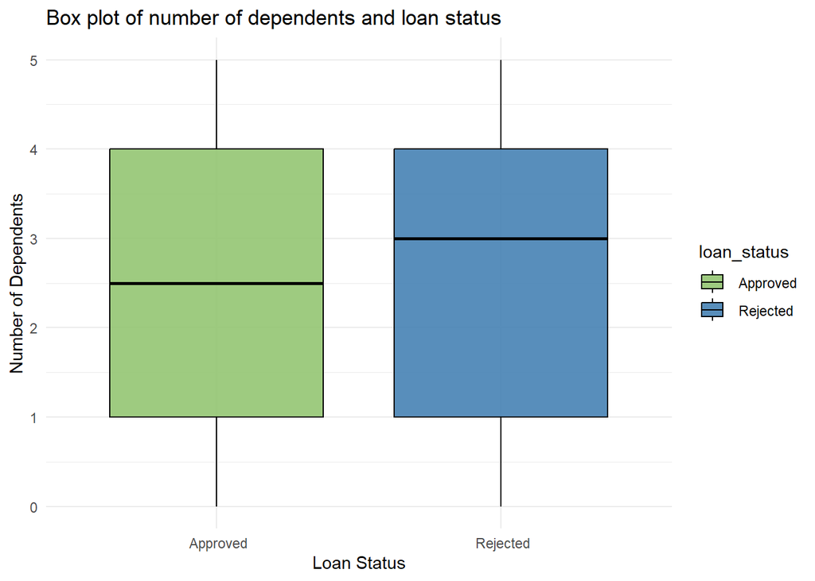

```r
ggplot(data, aes(y = no_of_dependents, x = loan_status, fill = loan_status)) +
  geom_boxplot(binwidth = 0.5, color = "black", alpha = 0.9) +
  labs(
    title = "Box plot of number of dependents and loan status",
    x = "Loan Status",
    y = "Number of Dependents"
  ) +
  scale_fill_manual(values = c("#93C572", "#4682B4"))+theme_minimal()
```

```r
data <- data %>%
  mutate(self_employed = str_trim(self_employed))
```

```r
data <- data %>%
  mutate(education = str_trim(education))
```

```r
data <- data %>%
  mutate(loan_status = str_trim(loan_status))
```

```r
data$education<-as.factor(data$education)
data$self_employed<-as.factor(data$self_employed)
data$loan_status<-as.factor(data$loan_status)
```

```r
class(data$self_employed)
class(data$luxury_assets_value)
class(data$income_annum)
class(data$loan_status)
```

```r
str(data)
```

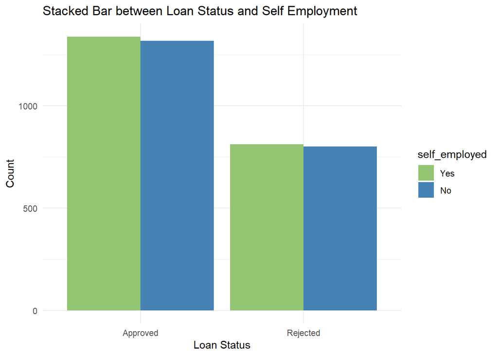

```r
data$self_employed <- factor(data$self_employed, levels = c("Yes", "No", "Other"))

ggplot(data, aes(x =loan_status, fill = self_employed)) +
  geom_bar(position = "dodge", stat = "count") +
  labs(title = "Stacked Bar between Loan Status and Self Employment",
       x = "Loan Status",
       y = "Count",
       fill = "self_employed") + scale_fill_manual(values = c("Yes" = "#93C572", "No" = "#4682B4", "Other" = "gray")) +
  theme_minimal()
```

```r
data1 <- data
data1$self_employed <- as.integer(data$self_employed == "Yes")
data1$loan_status <- as.integer(data$loan_status == "Approved")
data1$education <- as.integer(data$education == "Graduate")
```

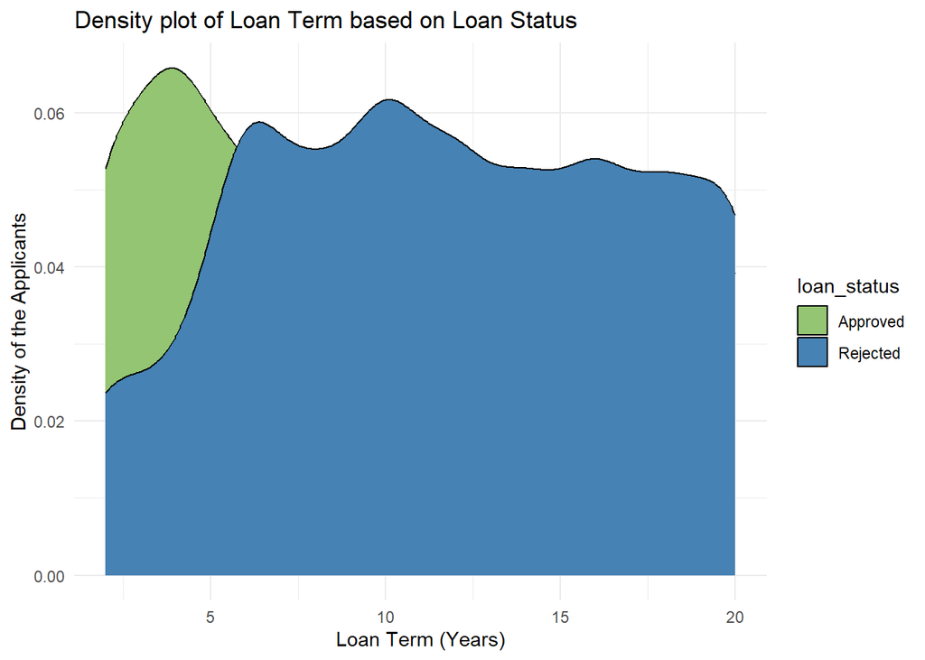

```r
ggplot(data, aes(x = loan_term,fill=loan_status)) +
  geom_density() +
  theme_bw() +
  theme() +
  labs(
    title = "Density plot of Loan Term based on Loan Status",
    x = "Loan Term (Years)",
    y = "Density of the Applicants"
  )+scale_fill_manual(values = c("#93C572", "#4682B4")) + theme_minimal()
```

### Scatter Plot between Cibil Score and Loan Amount

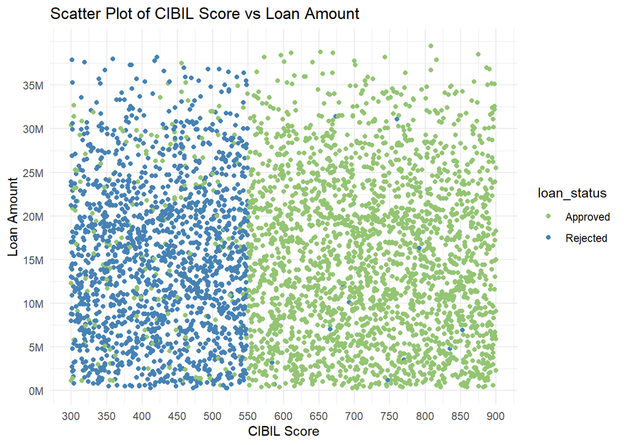

```r
ggplot(data, aes(x= cibil_score, y = loan_amount, color = loan_status)) +
  geom_point() +
  labs(title = "Scatter Plot of CIBIL Score vs Loan Amount",
       x = "CIBIL Score",
       y = "Loan Amount") +
  scale_color_manual(values = c("#93C572", "#4682B4")) + scale_x_continuous(breaks = seq(min(data$cibil_score), max(data$cibil_score), by = 50))+scale_y_continuous(labels = comma_format(scale = 1e-6,suffix = "M"), breaks = seq(0, 35000000, by = 5000000)) + theme_minimal()
```

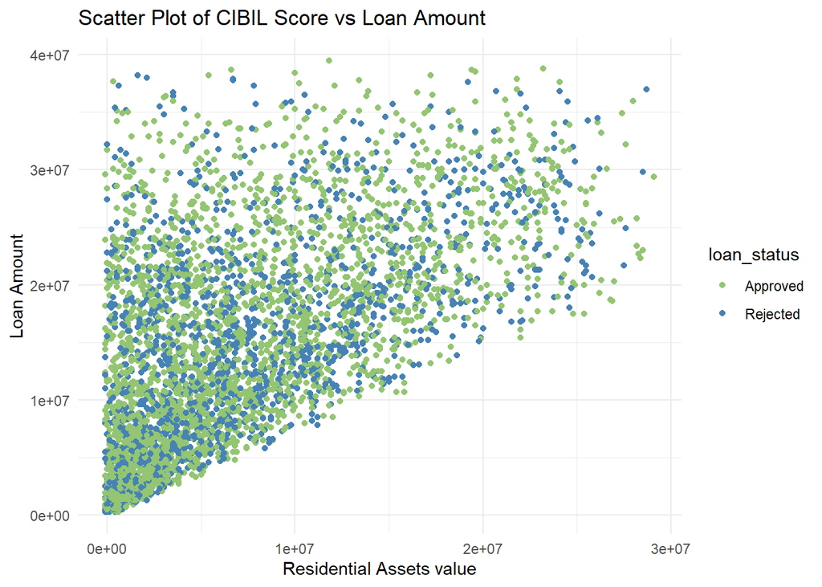

```r
ggplot(data, aes(x= residential_assets_value, y = loan_amount, color = loan_status)) +
  geom_point() +
  labs(title = "Scatter Plot of CIBIL Score vs Loan Amount",
       x = "Residential Assets value",
       y = "Loan Amount") +scale_color_manual(values = c("#93C572", "#4682B4")) + theme_minimal()
```

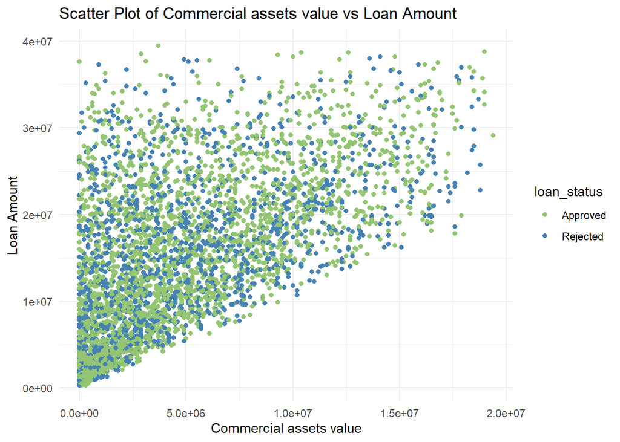

```r
ggplot(data, aes(x= commercial_assets_value, y = loan_amount, color = loan_status)) +
  geom_point() +
  labs(title = "Scatter Plot of Commercial assets value vs Loan Amount",
       x = "Commercial assets value",
       y = "Loan Amount") +scale_color_manual(values = c("#93C572", "#4682B4")) + theme_minimal()
```

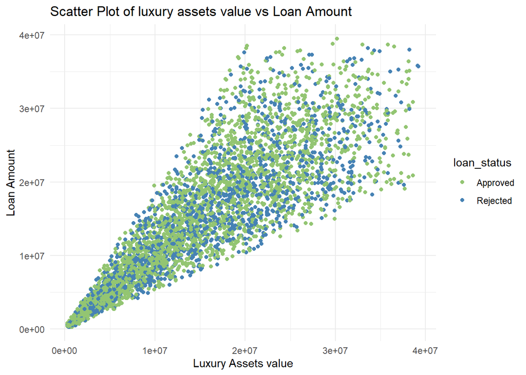

```r
ggplot(data, aes(x= luxury_assets_value, y = loan_amount, color = loan_status)) +
  geom_point() +
  labs(title = "Scatter Plot of luxury assets value vs Loan Amount",
       x = "Luxury Assets value",
       y = "Loan Amount") +scale_color_manual(values = c("#93C572", "#4682B4")) + theme_minimal()
```

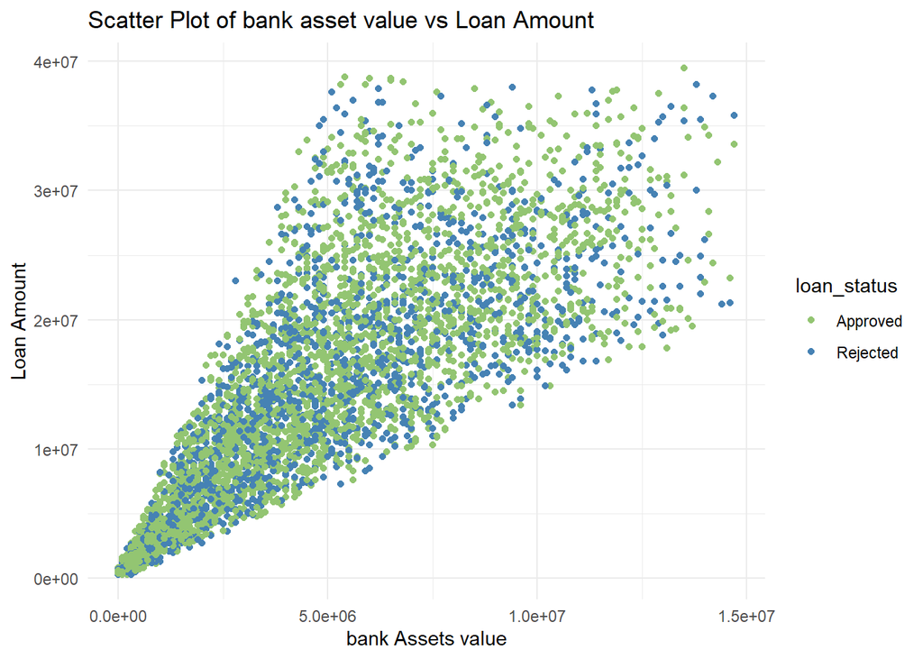

```r
ggplot(data, aes(x= bank_asset_value, y = loan_amount, color = loan_status)) +
  geom_point() +
  labs(title = "Scatter Plot of bank asset value vs Loan Amount",
       x = "bank Assets value",
       y = "Loan Amount") +scale_color_manual(values = c("#93C572", "#4682B4")) + theme_minimal()
```

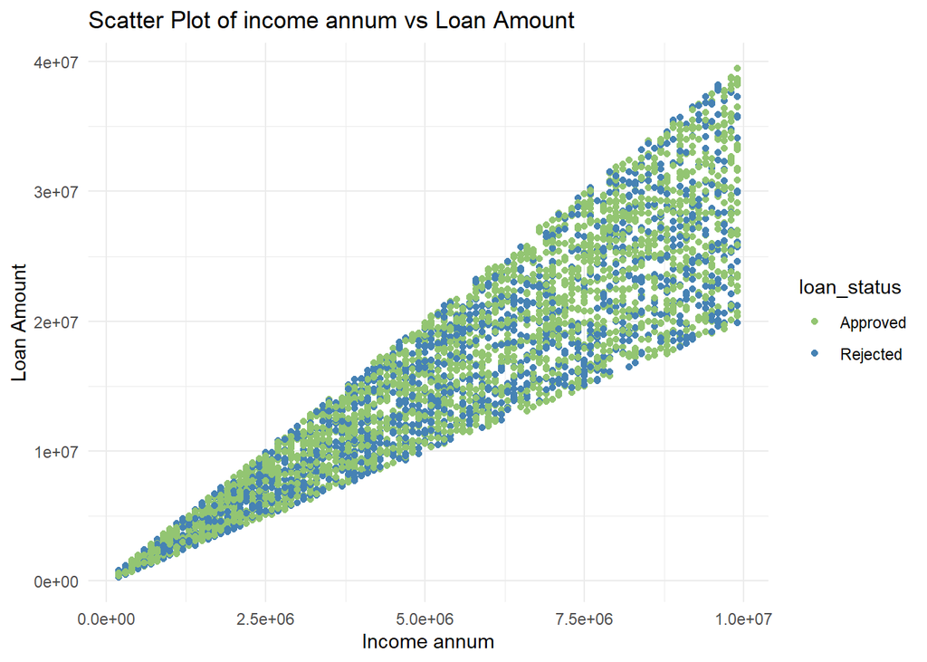

```r
ggplot(data, aes(x= income_annum, y = loan_amount, color = loan_status)) +
  geom_point() +
  labs(title = "Scatter Plot of income annum vs Loan Amount",
       x = "Income annum",
       y = "Loan Amount") +scale_color_manual(values = c("#93C572", "#4682B4")) + theme_minimal()
```

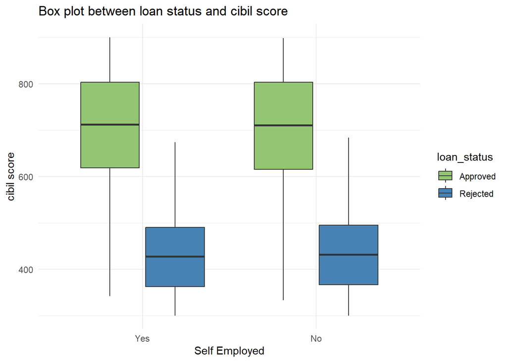

```r
ggplot(data, aes(x = self_employed, y = cibil_score, fill=loan_status)) +
  geom_boxplot(outlier.shape = NA) +
  labs(title = "Box plot between loan status and cibil score",
       x = "Self Employed",
       y = "cibil score")+
  scale_fill_manual(values = c("Approved" = "#93C572", "Rejected" = "#4682B4"))+
  theme_minimal()
```

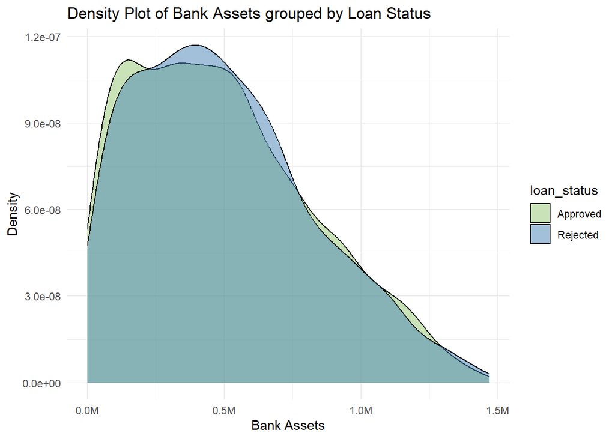

```r
ggplot(data, aes(x = bank_asset_value, fill = loan_status)) +
  geom_density(alpha = 0.5) +
  labs(title = "Density Plot of Bank Assets grouped by Loan Status",
       x = "Bank Assets",
       y = "Density")+scale_fill_manual(values = c("Approved" = "#93C572", "Rejected" = "#4682B4"))+
  theme_minimal()+scale_x_continuous(labels = comma_format(scale = 1e-7,suffix = "M"))
```

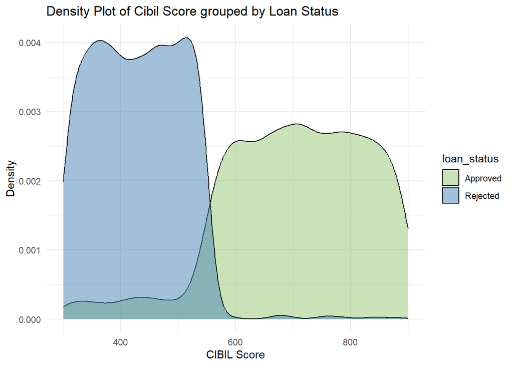

```r
ggplot(data, aes(x = cibil_score, fill = loan_status)) +
  geom_density(alpha = 0.5) +
  labs(title = "Density Plot of Cibil Score grouped by Loan Status",
       x = "CIBIL Score",
       y = "Density")+scale_fill_manual(values = c("Approved" = "#93C572", "Rejected" = "#4682B4"))+
  theme_minimal()
```

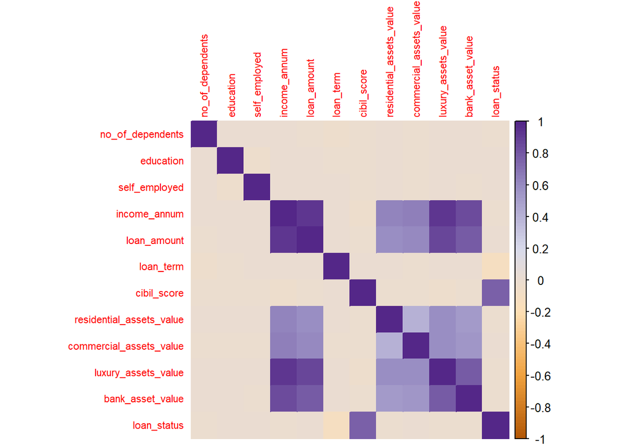

```r
x <- cor(data1)
corrplot(x, type = "full", tl.cex = 0.7, method = "color", col = colorRampPalette(brewer.pal(6, "PuOr"))(100))
```

#STATISTICAL TEST

## T-Test on Loan Status (Approval/Rejection) and Cibil Score

```
##
##  Welch Two Sample t-test
##
## data:  Approved$cibil_score and rejected$cibil_score
## t = 88, df = 4263, p-value <2e-16
## alternative hypothesis: true difference in means is not equal to 0
## 95 percent confidence interval:
##  268 280
## sample estimates:
## mean of x mean of y
##       703       429
```

Null Hypothesis ($H_{0}$): CIBIL score has no significant association with loan status.

Alternate Hypothesis ($H_{A}$): CIBIL score has significant association with loan status.

The `p-value` $0$, is very less than the standard `alpha` value of 0.05, hence, we reject the NULL hypothesis and conclude that CIBIL score has significant association with the probability of loan approval.

## Chi-square test between Education and Loan Status

```
##
##  Pearson's Chi-squared test with Yates' continuity correction
##
## data:  c
## X-squared = 0.08, df = 1, p-value = 0.8
```

Null Hypothesis ($H_{0}$): Education level and loan status are independent of each other.

Alternate Hypothesis ($H_{A}$): Education level and loan status are dependent on each other.

Education level and loan status have a high `p-value` of $0.772$. Thus, we cannot reject null hypothesis and by therefore accepting the null hypothesis, we conclude that the education level of an applicant has no significant impact on loan approval.

## T-Test between Loan Status and Bank Asset Value

```
##
##  Welch Two Sample t-test
##
## data:  Approved$bank_asset_value and rejected$bank_asset_value
## t = -0.4, df = 3453, p-value = 0.7
## alternative hypothesis: true difference in means is not equal to 0
## 95 percent confidence interval:
##  -245677  154809
## sample estimates:
## mean of x mean of y
##   4959526   5004960
```

Null Hypothesis ($H_{0}$): Bank asset value and loan status are independent of each other.

Alternative Hypothesis ($H_{A}$): Bank asset value and loan status are dependent on each other.

## T-Test between Loan Status and Residential Assets Value

```
##
##  Welch Two Sample t-test
##
## data:  Approved$residential_assets_value and rejected$residential_assets_value
## t = -0.9, df = 3400, p-value = 0.3
## alternative hypothesis: true difference in means is not equal to 0
## 95 percent confidence interval:
##  -595310  209937
## sample estimates:
## mean of x mean of y
##   7399812   7592498
```

Null Hypothesis ($H_{0}$): There is no significant association between the values of residential asset and loan approval status.

Alternative Hypothesis ($H_{A}$): There is a significant association between the values of residential asset and loan approval status. With a `p-value` of $0.348$, we cannot reject the null hypothesis and thus, we conclude from the null hypothesis that there exists no significant association between residential assets value and loan status.

## T-test between number of dependents and loan status

```
##
##  Welch Two Sample t-test
##
## data:  Approved$no_of_dependents and rejected$no_of_dependents
## t = -1, df = 3400, p-value = 0.2
## alternative hypothesis: true difference in means is not equal to 0
## 95 percent confidence interval:
##  -0.1683  0.0416
## sample estimates:
## mean of x mean of y
##      2.47      2.54
```

Null Hypothesis ($H_{0}$): There is no significant association between the number of dependents and loan approval status.

Alternative Hypothesis ($H_{A}$): There is a significant association between the number of dependents and loan approval status.

With a `p-value` of $0.237$, we cannot reject the null hypothesis and thus, by accepting the null hypothesis, we can say that there exists no significant association between number of dependents and loan status.

## T-test between luxury assets value and loan status

```
##
##  Welch Two Sample t-test
##
## data:  a$luxury_assets_value and r$luxury_assets_value
## t = -1, df = 3442, p-value = 0.3
## alternative hypothesis: true difference in means is not equal to 0
## 95 percent confidence interval:
##  -851752  271073
## sample estimates:
## mean of x mean of y
##  15016604  15306944
```

Null Hypothesis ($H_{0}$): The luxury assets value of an applicant has no significant association with their loan status.

Alternate Hypothesis ($H_{A}$): The luxury assets value of an applicant has significant association with their loan status.

With a `p-value` of $0.311$, we cannot reject the null hypothesis and thus, we conclude that the luxury assets value of an applicant has no significant association with their loan status.

```
## Pearson Correlation Coefficient: 0.00844
```

```
## p-value: 0.582
```

The small value of the Pearson correlation coefficient $0.008$ suggests a weak relationship between `loan_term` and `loan_amount`. The high `p-value` $0.582$ indicates that the resultant correlation is not statistically significant.

# Model Selection

### Regression problem

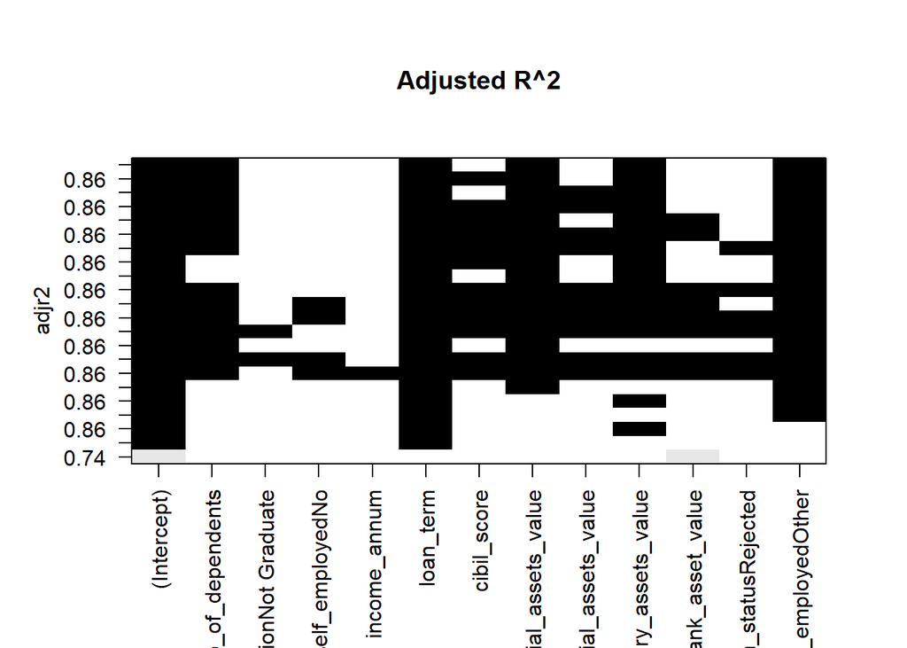

```r
library("leaps")

reg.best10 <- regsubsets(loan_amount~. , data = data, nvmax = 10, nbest = 2, method = "exhaustive")

plot(reg.best10, scale = "adjr2", main = "Adjusted R^2")
```

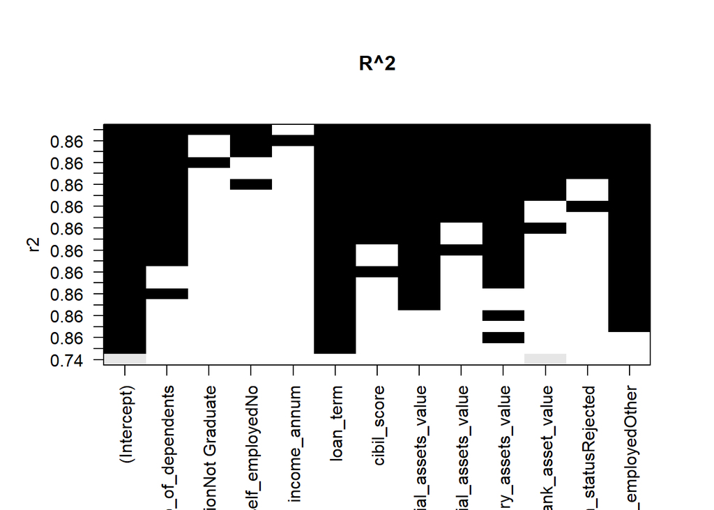

```r
plot(reg.best10, scale = "r2", main = "R^2")
```

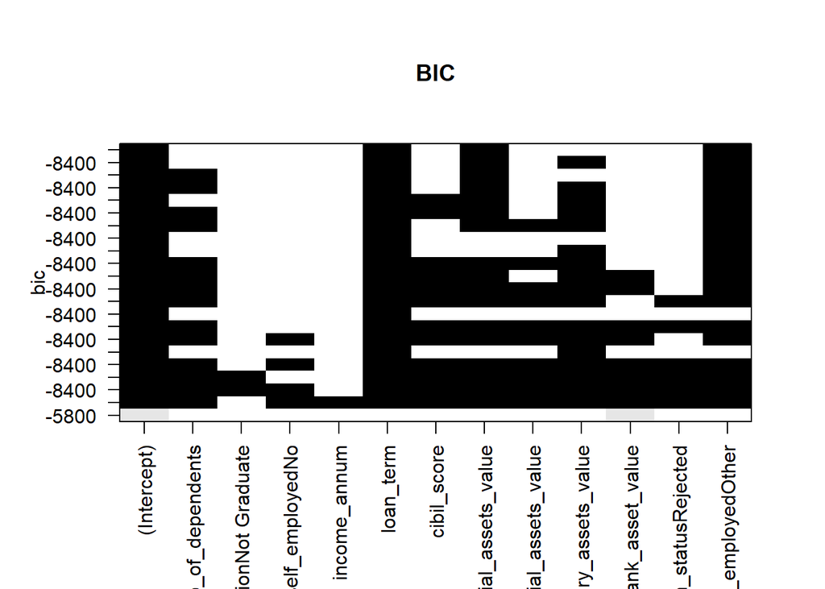

```r
# In the "leaps" package, we can use scale=c("bic","Cp","adjr2","r2")
plot(reg.best10, scale = "bic", main = "BIC")
```

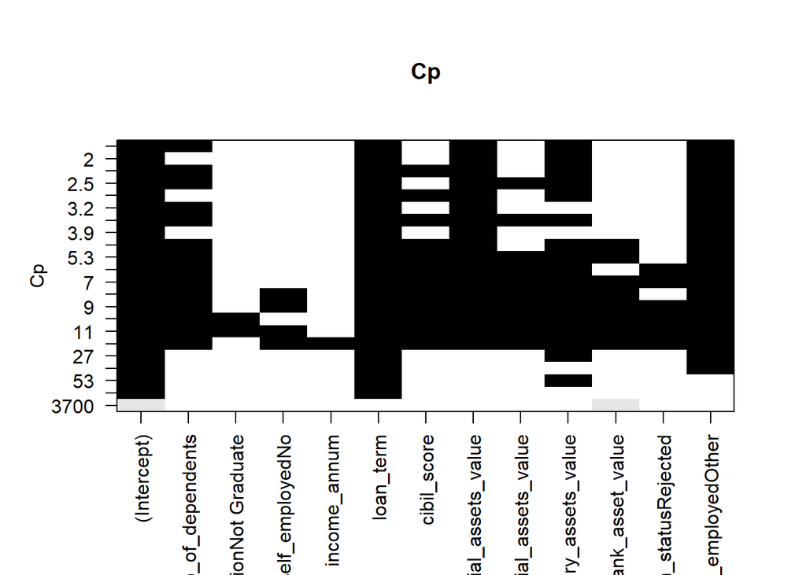

```r
plot(reg.best10, scale = "Cp", main = "Cp")
```

```r
summary(reg.best10)
```

The `regsubsets()` selection method aims to find the best subset of predictor variables that minimizes or maximizes a chosen criterion, such as Adjusted R-squared (adjr2), R-squared (r2), Bayesian Information Criterion (BIC), or Mallows’ Cp.

In case of the Adjusted R-squared plot, the best possible set of predictors are found to be: `no_of_dependents`, `loan_term`, `income_annum`, `commercial_assests_value`, `cibil_score` and `loan_status`. In case of the R-squared plot, the best possible set of predictors are found to be: `no_of_dependents`, `loan_term`, `income_annum`, `commercial_assests_value`, `cibil_score` and `loan_status`. From the BIC plot we can observe that the best possible set of predictors are found to be: `no_of_dependents`, `loan_term`, `income_annum`, `residential_assets_value`, `commercial_assests_value`, `cibil_score` and `loan_status`. From the Cp Mallow plot we can observe that the best possible set of predictors are found to be: `no_of_dependents`, `income_annum`, `residential_assets_value`, `commercial_assests_value`, `cibil_score` and `loan_status`.

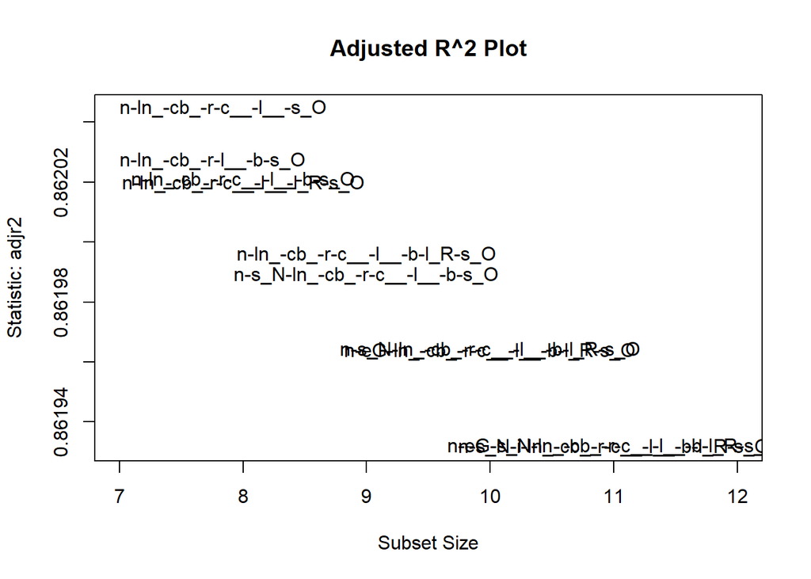

```r
summaryRegForward = summary(reg.best10)
# Adjusted R2
car::subsets(reg.best10, statistic="adjr2", legend = FALSE, min.size = 7, main = "Adjusted R^2 Plot")
```

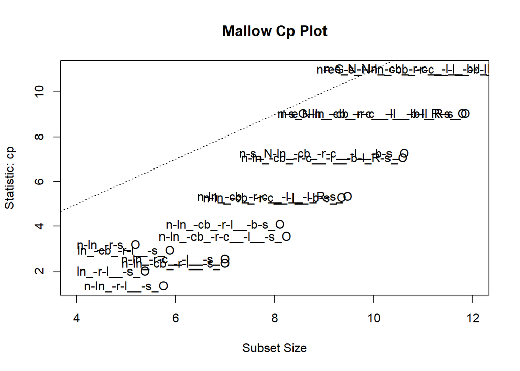

```r
subsets(reg.best10, statistic="cp", legend = FALSE, min.size = 4, main = "Mallow Cp Plot")
abline(a = 1, b = 1, lty = 3)
```

### Classification Problem

```r
library("bestglm")
res.bestglm <- bestglm(Xy = data, family = binomial,
            IC = "AIC",
            method = "exhaustive")
summary(res.bestglm)
```

```r
res.bestglm$BestModels
summary(res.bestglm$BestModels)
```

# Model Creation

In our comprehensive analysis, we adopt a dual-pronged approach to enhance the predictive capabilities of our model. Specifically, we employ both regression and classification techniques to predict distinct aspects of the loan application process—loan amount and loan status, respectively.

## Train Test Split

The dataset was initially explored to understand the distribution of the target variable `loan_status` This binary classification variable represents whether a loan was approved or not. To ensure model generalization, the data was then split into training (80%) and test (20%) sets using a seed for reproducibility.

```r
table(data$loan_status)
table(data$loan_status)[2] / sum(table(data$loan_status))


set.seed(1)
data_train_rows = sample(1:nrow(data),
                              round(0.8 * nrow(data), 0),
                              replace = FALSE)

length(data_train_rows) / nrow(data)

data_train = data[data_train_rows, ]
data_test = data[-data_train_rows, ]

nrow(data_train)
nrow(data_test)
```

## Regression

### Linear Regression

A linear regression model was constructed using the `lm()` function in R, predicting loan_amount based on various features, including `no_of_dependents`, `loan_term`, `income_annum`, `commercial_assets_value`, `cibil_score`, and `loan_status.`

```r
model<-lm(loan_amount~no_of_dependents+loan_term+income_annum+commercial_assets_value+cibil_score+loan_status,data=data)
summary(model)

ezids::xkabledply(model,title = "Summary of loan amount prediction")
ezids::xkablevif(model)
```

The summary statistics and variance inflation factor (VIF) were analyzed for insights. which gives us values lesser than 3 which means there is no multicollinearity in our features.

### Results

```r
model <- lm(loan_amount ~ no_of_dependents + loan_term + income_annum +
            commercial_assets_value + cibil_score + loan_status, data = data_train)

train_predictions <- predict(model, newdata = data_train)
test_predictions <- predict(model, newdata = data_test)
plot_data <- data.frame(Actual = data_test$loan_amount, Predicted = test_predictions)


train_r_squared <- cor(data_train$loan_amount, train_predictions)^2
cat("Training R-squared:", train_r_squared, "\n")
```

```
## Training R-squared: 0.862
```

```r
test_r_squared <- cor(data_test$loan_amount, test_predictions)^2
cat("Testing R-squared:", test_r_squared, "\n")
```

```
## Testing R-squared: 0.862
```

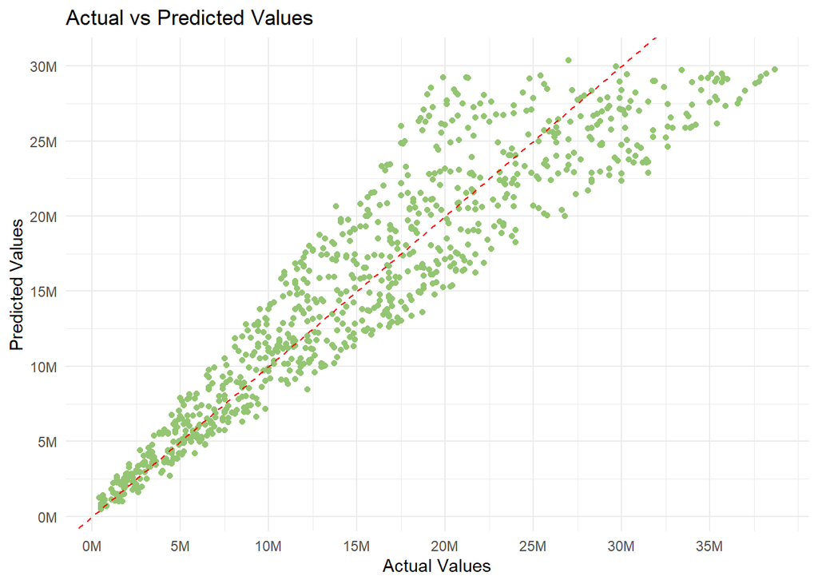

```r
ggplot(plot_data, aes(x = Actual, y = Predicted)) +
  geom_point(color="#93C572") +
  geom_abline(intercept = 0, slope = 1, linetype = "dashed", color = "red") +
  labs(title = "Actual vs Predicted Values",
       x = "Actual Values",
       y = "Predicted Values")+scale_x_continuous(labels = comma_format(scale = 1e-6,suffix = "M"), breaks = seq(0, 35000000, by = 5000000))+scale_y_continuous(labels = comma_format(scale = 1e-6,suffix = "M"), breaks = seq(0, 35000000, by = 5000000))+theme_minimal()
```

The scatter plot depicts the relationship between actual and predicted loan amounts, with a dashed red line marking the ideal prediction scenario. R-squared values of 0.862 for both training and testing highlight the model’s robust explanatory power and generalization to unseen data.

## Classification

### Logistic Regression

This study employs logistic regression to build a predictive model for loan status based on key features in a given dataset. The logistic regression model is constructed using the `glm()` function in R, with an emphasis on variables such as the number of dependents, annual income, loan amount, loan term, credit score (CIBIL score), luxury assets value, and bank assets value. The summary output of the model is analyzed to assess the significance and impact of each predictor on loan status.

### Model building

```r
Logit <- glm(loan_status ~ no_of_dependents  + income_annum+loan_amount+loan_term+cibil_score+luxury_assets_value+bank_asset_value, data = data_train, family = "binomial")
summary_output<-summary(Logit)
summary_output
```

### Feature Importance

```r
ezids::xkabledply(Logit, title =" Summary of logistic Regression for loan status")
```

Summary of logistic Regression for loan status

|  | Estimate | Std. Error | z value | Pr(>\|z\|) |
| --- | --- | --- | --- | --- |
| (Intercept) | 11.2729 | 0.4762 | 23.671 | 0.000 |
| no_of_dependents | 0.0066 | 0.0385 | 0.171 | 0.864 |
| income_annum | 0.0000 | 0.0000 | 5.512 | 0.000 |
| loan_amount | 0.0000 | 0.0000 | -6.715 | 0.000 |
| loan_term | 0.1491 | 0.0127 | 11.718 | 0.000 |
| cibil_score | -0.0246 | 0.0009 | -26.587 | 0.000 |
| luxury_assets_value | 0.0000 | 0.0000 | -1.353 | 0.176 |
| bank_asset_value | 0.0000 | 0.0000 | -1.097 | 0.273 |

```r
expcoeff = exp(coef(Logit))
# expcoeff
ezids::xkabledply( as.table(expcoeff), title = "Exponential of coefficients in Logit Reg" )
```

Exponential of coefficients in Logit Reg

|  | x |
| --- | --- |
| (Intercept) | 7.87e+04 |
| no_of_dependents | 1.01e+00 |
| income_annum | 1.00e+00 |
| loan_amount | 1.00e+00 |
| loan_term | 1.16e+00 |
| cibil_score | 9.76e-01 |
| luxury_assets_value | 1.00e+00 |
| bank_asset_value | 1.00e+00 |

### Data imbalance

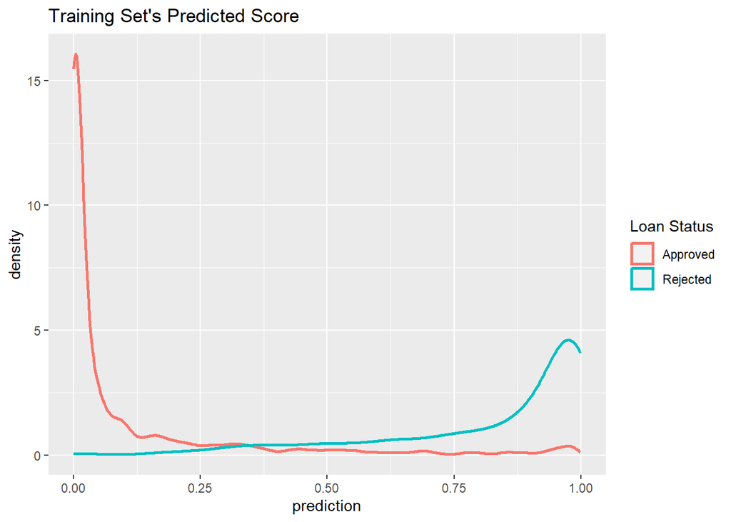

```r
# prediction
data_train$prediction <- predict( Logit, newdata = data_train, type = "response" )
data_test$prediction  <- predict( Logit, newdata = data_test , type = "response" )

# distribution of the prediction score grouped by known outcome
ggplot( data_train, aes( prediction, color = as.factor(loan_status) ) ) +
geom_density( size = 1 ) +
ggtitle( "Training Set's Predicted Score" )+ labs(color = "Loan Status")
```

- Examining the data imbalance graph reveals that the distribution of approved and rejected candidates is both left and right skewed. Consequently, relying solely on accuracy score and ROC score may not be sufficient for our prediction analysis.

### Train and test metrices

```r
train_predictions <- predict(Logit, newdata = data_train, type = "response")

train_predictions_class <- ifelse(train_predictions > 0.49, 1, 0)

train_conf_matrix <- table(Predicted = train_predictions_class, Actual = data_train$loan_status)

train_accuracy <- sum(diag(as.matrix(train_conf_matrix))) / sum(train_conf_matrix)
print(paste("Training Accuracy:", round(train_accuracy * 100, 2), "%"))
```

```
## [1] "Training Accuracy: 91.45 %"
```

```r
test_predictions <- predict(Logit, newdata = data_test, type = "response")

test_predictions_class <- ifelse(test_predictions > 0.49, 1, 0)

test_conf_matrix <- table(Predicted = test_predictions_class, Actual = data_test$loan_status)


test_accuracy <- sum(diag(as.matrix(test_conf_matrix))) / sum(test_conf_matrix)
print(paste("Test Accuracy:", round(test_accuracy * 100, 2), "%"))
```

```
## [1] "Test Accuracy: 93.09 %"
```

```r
train_precision <- train_conf_matrix[2, 2] / sum(train_conf_matrix[, 2])
print(paste("Training Precision:", round(train_precision*100, 2), "%"))
```

```
## [1] "Training Precision: 88.92 %"
```

```r
train_recall <- train_conf_matrix[2, 2] / sum(train_conf_matrix[2, ])
print(paste("Training Recall:", round(train_recall*100, 2), "%"))
```

```
## [1] "Training Recall: 88.51 %"
```

```r
test_precision <- test_conf_matrix[2, 2] / sum(test_conf_matrix[, 2])
print(paste("Test Precision:", round(test_precision*100, 2), "%"))
```

```
## [1] "Test Precision: 90.68 %"
```

```r
test_recall <- test_conf_matrix[2, 2] / sum(test_conf_matrix[2, ])
print(paste("Test Recall:", round(test_recall*100, 2), "%"))
```

```
## [1] "Test Recall: 90.97 %"
```

**In the logistic regression model, the following performance metrics were observed:**

- Training Accuracy: 91.45%
- Test Accuracy: 93.09%
- Training Precision: 88.92%
- Training Recall: 88.51%
- Test Precision: 90.68%
- Test Recall: 90.97%

These metrics provide an overview of the model’s ability to correctly predict loan approval status. The high accuracy and precision scores indicate a strong predictive performance. Additionally, balanced recall scores suggest that the model effectively captures both approved and rejected instances. This comprehensive evaluation demonstrates the logistic regression model’s robustness in making accurate predictions on both the training and test datasets.

### Confusion matrix

```r
library("regclass")
# confusion_matrix(admitLogit)
ezids::xkabledply( confusion_matrix(Logit), title = "Confusion matrix from Logit Model" )
```

Confusion matrix from Logit Model

|  | Predicted Approved | Predicted Rejected | Total |
| --- | --- | --- | --- |
| Actual Approved | 1979 | 145 | 2124 |
| Actual Rejected | 150 | 1141 | 1291 |
| Total | 2129 | 1286 | 3415 |

### Receiver-Operator-Characteristic (ROC) curve and Area-Under-Curve (AUC)

Receiver-Operator-Characteristic (ROC) curve and Area-Under-Curve (AUC) measures the true positive rate (or sensitivity) against the false positive rate (or specificity). The area-under-curve is always between 0.5 and 1. Values higher than 0.8 is considered good model fit.

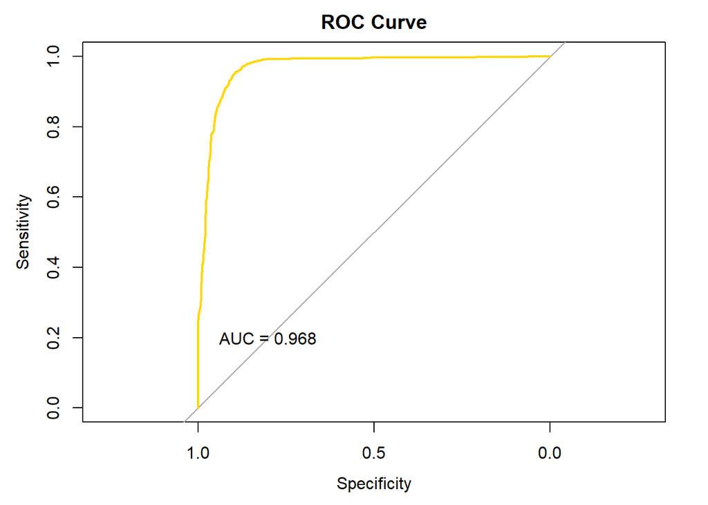

```r
library("pROC")
prob=predict(Logit, type = "response" )
data_train$prob=prob
h <- roc(loan_status~prob, data=data_train)
roc_curve=auc(h) # area-under-curve prefer 0.8 or higher.
k_logit=roc_curve
#plot(h)
plot(h, main = "ROC Curve", col = "gold", lwd = 2)
text(0.8, 0.2, paste("AUC =", round(auc(h), 3)), col = "black")
```

```r
# unloadPkg("pROC")
```

### McFadden pseudo R-squared

```r
NullLogit <- glm(loan_status ~ 1, data = data, family = "binomial")
mcFadden = 1 - logLik(Logit)/logLik(NullLogit)
mcFadden
```

In logistic regression, the log likelihood value is 0.729 with 8 degrees of freedom. This is used to calculate McFadden’s pseudo R-squared, indicating how well the model fits the data compared to a simple intercept-only model. A higher pseudo R-squared value suggests a better fit, but there’s no universal threshold. The log likelihood of 0.729 contributes to assessing the goodness-of-fit in our logistic regression analysis.

## Data preprocessing

### Factoring the data

```r
data_train$self_employed<-as.numeric(data_train$self_employed)
data_test$self_employed<-as.numeric(data_test$self_employed)
str(data_train)
```

## KNN Model creation

### Finding the best K value

```r
library("class")
library("ggplot2")
chooseK = function(k, train_set, val_set, train_class, val_class){

  set.seed(1)
  class_knn = knn(train = train_set,
                  test = val_set,
                  cl = train_class,
                  k = k)

  tab = table(class_knn, val_class)

  accu = sum(tab[row(tab) == col(tab)]) / sum(tab)
  cbind(k = k, accuracy = accu)
}


knn_different_k = sapply(seq(1, 21, by = 2),
                         function(x) chooseK(x,
                                             train_set = data_train[, c("no_of_dependents","self_employed" ,"income_annum","loan_amount","loan_term","cibil_score","luxury_assets_value","bank_asset_value")],
                                             val_set = data_test[, c("no_of_dependents","self_employed" ,"income_annum","loan_amount","loan_term","cibil_score","luxury_assets_value","bank_asset_value")],
                                             train_class = data_train[, "loan_status"],
                                             val_class = data_test[, "loan_status"]))

str(knn_different_k)
```

```
##  num [1:2, 1:11] 1 0.542 3 0.573 5 ...
```

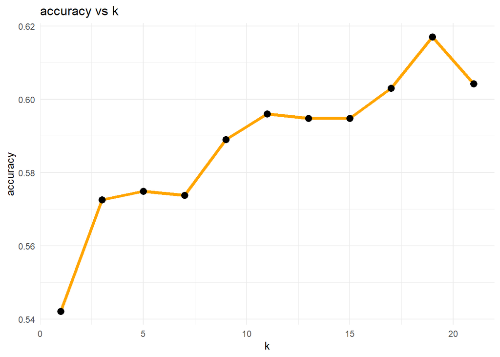

```r
knn_different_k = data.frame(k = knn_different_k[1,],
                             accuracy = knn_different_k[2,])



ggplot(knn_different_k,
       aes(x = k, y = accuracy)) +
  geom_line(color = "orange", size = 1.5) +
  geom_point(size = 3) +
  labs(title = "accuracy vs k")+theme_minimal()
```

## KNN Evaluation metrices

### For training

```r
train_predictions <- knn(train = data_train[, c("no_of_dependents","self_employed","income_annum","loan_amount","loan_term","cibil_score","luxury_assets_value","bank_asset_value")],
                          test = data_train[, c("no_of_dependents","self_employed","income_annum","loan_amount","loan_term","cibil_score","luxury_assets_value","bank_asset_value")],
                          cl = data_train[, "loan_status"],
                          k = 18)


train_conf_matrix <- table(Predicted = train_predictions, Actual = data_train$loan_status)

print(train_conf_matrix)

train_accuracy <- sum(diag(as.matrix(train_conf_matrix))) / sum(train_conf_matrix)
print(paste("Training Accuracy:", round(train_accuracy * 100, 2), "%"))
```

### For testing

```r
library("class")
set.seed(1)
bank_18NN = knn(train = data_train[,c("no_of_dependents","self_employed","income_annum","loan_amount","loan_term","cibil_score","luxury_assets_value","bank_asset_value")],test =data_test[,c("no_of_dependents","self_employed","income_annum","loan_amount","loan_term","cibil_score","luxury_assets_value","bank_asset_value")],cl = data_train[, "loan_status"],k = 18)
str(bank_18NN)
length(bank_18NN)
table(bank_18NN)
conf_matrix<-table(Predicted = bank_18NN, Actual = data_test$loan_status)
accuracy <- sum(diag(as.matrix(conf_matrix))) / sum(conf_matrix)
print(paste("Test Accuracy:", round(accuracy * 100, 2), "%"))
```

### Confusion matrix

```r
library("gmodels")
IRISPREDCross <- CrossTable(data_test[,"loan_status"], bank_18NN, prop.chisq = FALSE)
```

### Testing results

```r
library("caret")
cm = confusionMatrix(bank_18NN, reference = as.factor(data_test[, "loan_status"]) )
cm
precision <- cm$byClass["Precision"]
recall <- cm$byClass["Recall"]

print(paste("Precision:", round(precision, 2)))
print(paste("Recall:", round(recall, 2)))
```

### AUC ROC curve for KNN

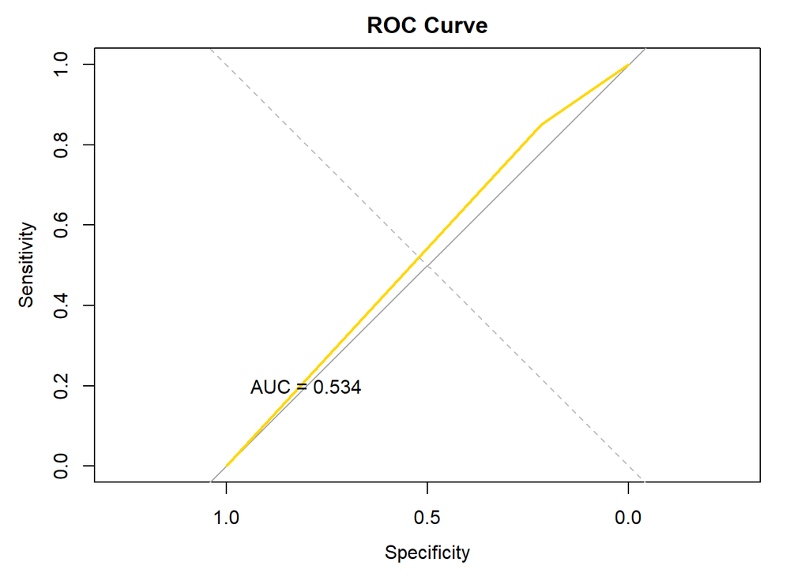

```r
library("class")
library("pROC")

set.seed(1)

roc_curve <- roc(ifelse(data_test[, "loan_status"] == "Approved", 1, 0), ifelse(bank_18NN == "Approved", 1, 0))

plot(roc_curve, main = "ROC Curve", col = "gold", lwd = 2)

text(0.8, 0.2, paste("AUC =", round(auc(roc_curve), 3)), col = "black")

abline(a = 0, b = 1, col = "gray", lty = 2)
```

```r
k<-auc(roc_curve)
```

## Decision Tree model

### Training

```r
library(rpart)

tree_model <- rpart(loan_status ~ no_of_dependents + self_employed + income_annum +
                      loan_amount + loan_term + cibil_score + luxury_assets_value +
                      bank_asset_value, data = data_train, method = "class")

tree_predictions <- predict(tree_model, newdata = data_train, type = "class")

conf_matrix<-table(tree_predictions, data_train$loan_status)

accuracy <- sum(diag(as.matrix(conf_matrix))) / sum(conf_matrix)
print(paste("Train Accuracy:", round(accuracy * 100, 2), "%"))
```

### Testing

```r
library(rpart)

tree_model <- rpart(loan_status ~ no_of_dependents + self_employed + income_annum +
                      loan_amount + loan_term + cibil_score + luxury_assets_value +
                      bank_asset_value, data = data_train, method = "class")

tree_predictions <- predict(tree_model, newdata = data_test, type = "class")

conf_matrix<-table(tree_predictions, data_test$loan_status)

accuracy <- sum(diag(as.matrix(conf_matrix))) / sum(conf_matrix)
print(paste("Test Accuracy:", round(accuracy * 100, 2), "%"))
```

### Testing results

```r
library("caret")
cm = confusionMatrix(tree_predictions, reference = as.factor(data_test[, "loan_status"]) )
cm
precision <- cm$byClass["Precision"]
recall <- cm$byClass["Recall"]

print(paste("Precision:", round(precision, 2)))
print(paste("Recall:", round(recall, 2)))
```

### AUC ROC curve of decision trees

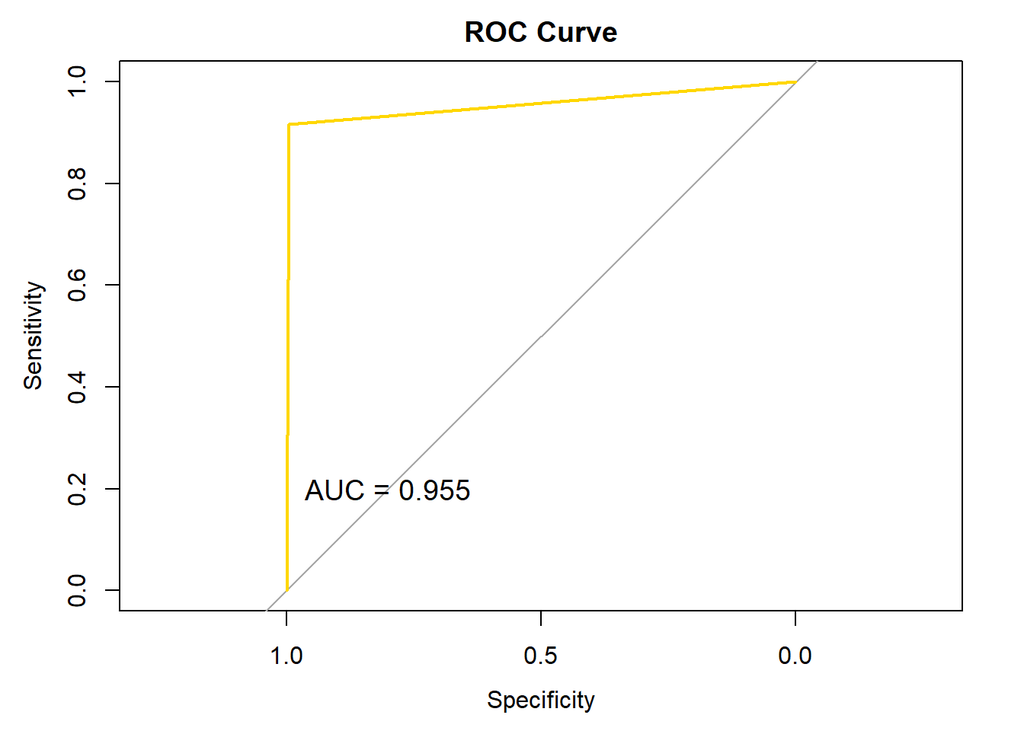

```r
library(pROC)
tree_predictions<-as.numeric(tree_predictions)
data_test$loan_status<-as.numeric(data_test$loan_status)

roc_curve2 <- roc(data_test$loan_status, tree_predictions)

plot(roc_curve2, main = "ROC Curve", col = "gold", lwd = 2)

auc_value <- auc(roc_curve2)
text(0.8, 0.2, paste("AUC =", round(auc_value, 3)), col = "black", cex = 1.2)
```

```r
cat("AUC:", auc_value, "\n")
```

### AUC Scores

```r
print(paste("AUC score of KNN", k))
```

```
## [1] "AUC score of KNN 0.533507682249101"
```

```r
print(paste("AUC score of decision Tress", auc_value))
```

```
## [1] "AUC score of decision Tress 0.95525498528931"
```

```r
print(paste("AUC score of Logistic regressor", k_logit))
```

```
## [1] "AUC score of Logistic regressor 0.967668021840323"
```

## Random forest

```r
library(randomForest)

rf_model <- randomForest(loan_status ~ no_of_dependents + income_annum + loan_amount +
                          loan_term + cibil_score + luxury_assets_value + bank_asset_value,
                          data = data_train, ntree = 500, importance = TRUE)

print(rf_model)
```

### Feature Importance Summary

```r
feature_importance <- importance(rf_model)
print(feature_importance)
```

```
##                     Approved Rejected MeanDecreaseAccuracy MeanDecreaseGini
## no_of_dependents        1.33     4.34                 3.74             15.8
## income_annum           15.75    14.63                21.43             37.2
## loan_amount            26.23    17.25                32.05             58.8
## loan_term              87.47    80.78               103.77             95.8
## cibil_score           383.23   399.68               440.78           1328.5
## luxury_assets_value    12.77    10.13                16.37             38.7
## bank_asset_value       10.79     9.59                14.86             29.8
```

## Model metrics random forest

### Training

```r
rf_predictions <- predict(rf_model, newdata = data_train)
conf_matrix<-table(rf_predictions, data_train$loan_status)

accuracy <- sum(diag(as.matrix(conf_matrix))) / sum(conf_matrix)
print(paste("Train Accuracy:", round(accuracy * 100, 2), "%"))
```

### Testing

```r
rf_predictions <- predict(rf_model, newdata = data_test, type = "class")

conf_matrix<-table(rf_predictions, data_test$loan_status)

accuracy <- sum(diag(as.matrix(conf_matrix))) / sum(conf_matrix)
print(paste("Test Accuracy:", round(accuracy * 100, 2), "%"))
```

### AUC ROC Curve

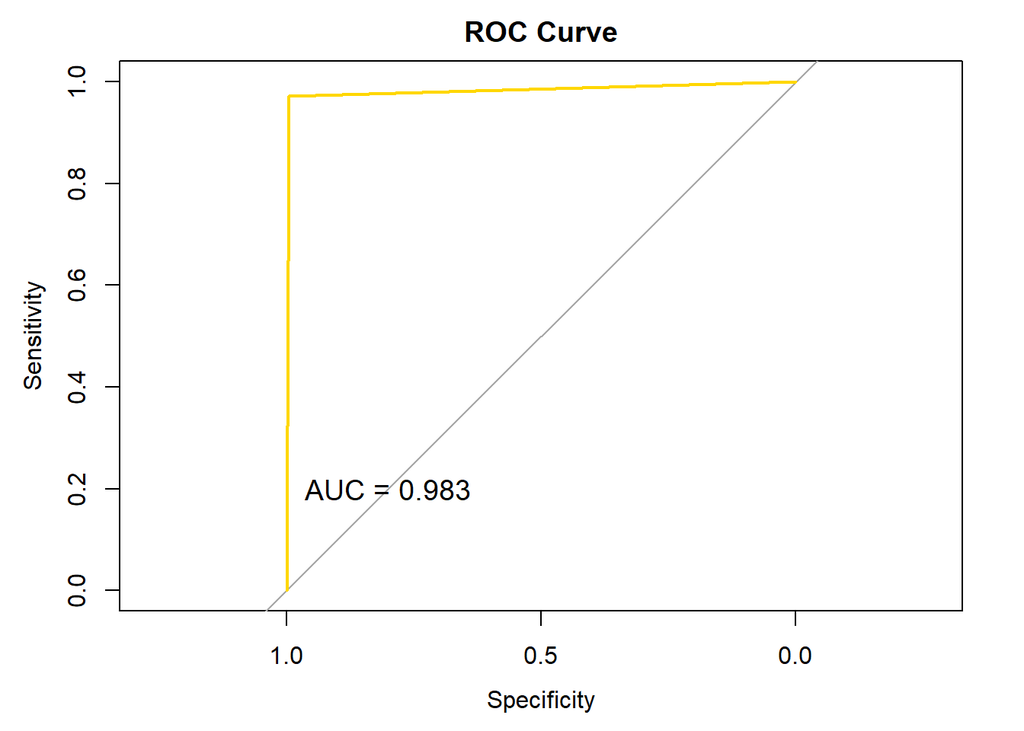

```r
library(pROC)
rf_predictions<-as.numeric(rf_predictions)
data_test$loan_status<-as.numeric(data_test$loan_status)

roc_curve2 <- roc(data_test$loan_status, rf_predictions)

plot(roc_curve2, main = "ROC Curve", col = "gold", lwd = 2)

auc_value <- auc(roc_curve2)
text(0.8, 0.2, paste("AUC =", round(auc_value, 3)), col = "black", cex = 1.2)
```

```r
cat("AUC:", auc_value, "\n")
```

## Model Result chart

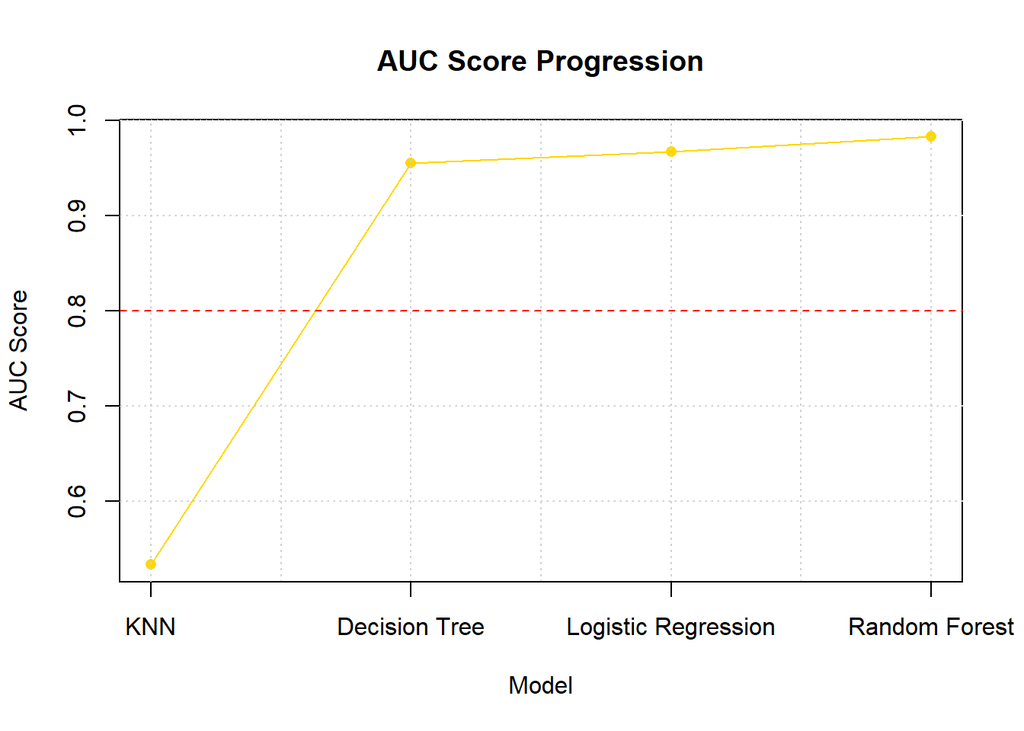

```r
auc_values <- c(0.5335, 0.9553, 0.9677,0.9832)
model_names <- c("KNN", "Decision Tree", "Logistic Regression","Random Forest")

plot(auc_values, type = "o", col = "gold", pch = 16, lty = 1,
     xlab = "Model", ylab = "AUC Score",
     main = "AUC Score Progression", xaxt = "n")

grid()

axis(side = 1, at = 1:length(model_names), labels = model_names)

abline(h = 0.8, col = "red", lty = 2)
```